# Una herramienta de apoyo para la detección de cáncer de mama basada en Redes Neuronales Convolucionales

## Introducción

El cáncer de mama es una enfermedad en la cual las células de la mama se multiplican sin control. Existen distintos tipos de cáncer de mama. El tipo de cáncer de mama depende de qué células de la mama se vuelven cancerosas.

El cáncer de mama puede comenzar en distintas partes de la mama. Las mamas constan de tres partes principales: lobulillos, conductos y tejido conectivo. Los lobulillos son las glándulas que producen leche. Los conductos son los tubos que transportan la leche al pezón. El tejido conectivo (formado por tejido fibroso y adiposo) rodea y sostiene todas las partes de la mama. La mayoría de los cánceres de mama comienzan en los conductos o en los lobulillos.

Referencia: https://www.cdc.gov/spanish/cancer/breast/basic_info/what-is-breast-cancer.htm

### Métodos actuales para la detección de cáncer de mama

- **Ultrasonido mamario.** Una máquina que usa ondas de sonido para producir imágenes, llamadas sonogramas, de áreas dentro de la mama.
- **Mamografía de diagnóstico.** Si usted tiene algún problema en la mama —como un bulto— o si un área de la mama se ve anormal en una mamografía de detección, el médico puede indicarle que se haga una mamografía diagnóstica. Esta es una radiografía más detallada de la mama.
- **Imagen por resonancia magnética (IRM) de las mamas.** Un tipo de escaneo del cuerpo que usa un imán conectado a una computadora. La resonancia magnética creará imágenes detalladas de áreas dentro de la mama.
- **Biopsia.** Esta es una prueba en la que se extirpa tejido o se saca líquido de la mama para estudiarse bajo el microscopio o para hacer más pruebas. Existen distintos tipos de biopsias (por ejemplo, aspiración con aguja fina, biopsia con aguja gruesa o biopsia abierta).

Referencia: https://www.cdc.gov/spanish/cancer/breast/basic_info/diagnosis.htm

### Otra propuesta: Termografías

Las termografías permiten detectar la temperatura en un cuerpo sin necesidad de contacto físico.  
Actualmente, se utiliza esta técnica para detectar la posible presencia de cáncer, ya que cuando se desarrolla un crecimiento canceroso, puede haber formación excesiva de vasos sanguíneos e inflamación en el tejido mamario. Estos se muestran en la imagen infrarroja como áreas con una temperatura más alta en la piel.

### Beneficios

Los proveedores de termografías recomiendan este método por las siguientes razones:

- Es un procedimiento no invasivo y sin contacto que no involucra la compresión del seno.
- No involucra exposición a la radiación y las personas pueden usarla con seguridad a lo largo del tiempo.
- Puede detectar cambios vasculares en el tejido mamario que puede indicar la presencia del cáncer de mama muchos años antes que otros métodos de detección.
- Puede detectar cambios en los senos con tejido denso e implantes.
- Los cambios hormonales y menstruales no afectan el procedimiento o los resultados.

Referencia: https://www.medicalnewstoday.com/articles/es/mamografia-y-termografia#mamografia

## Propuesta planteada

# Iniciando el proyecto

## Librerías necesarias

```python
import os
os.environ['TF_FORCE_GPU_ALLOW_GROWTH'] = 'true'
```

```python
import time
# from PIL import Image
from random import sample

import matplotlib.pyplot as plt
# from numpy import expand_dims
import numpy as np

import cv2
import tensorflow as tf
from tensorflow import keras

# from tensorflow.keras.preprocessing import image

from tensorflow.keras.preprocessing.image import ImageDataGenerator
from tensorflow.keras.preprocessing.image import img_to_array
from tensorflow.keras.preprocessing.image import load_img

from tensorflow.keras.optimizers import Adam

from tensorflow.keras.models import load_model
from tensorflow.keras.models import model_from_json, model_from_yaml

from tensorflow.keras.callbacks import ReduceLROnPlateau
from tensorflow.keras.callbacks import ModelCheckpoint
from tensorflow.keras.callbacks import EarlyStopping

from sklearn.metrics import classification_report, confusion_matrix

from tensorflow.keras.models import Sequential
from tensorflow.keras.layers import (
    BatchNormalization, Dense, Conv2D , MaxPool2D , Flatten , Dropout
)

print("Tensorflow version:", tf.__version__)
```

```
Tensorflow version: 2.8.0
```

## El approach

Se entrenará una red neuronal convolucional desde cero utilizando primeramente un dataset de neumonia, obtenido de [Kaggle](https://www.kaggle.com/). La arquitectura de red neuronal fue obtenida a partir de [esta libreta](https://www.kaggle.com/code/madz2000/pneumonia-detection-using-cnn-92-6-accuracy).

Se pretende utilizar primeramente este dataset para que la red aprenda los filtros básicos y no empezar con pesos aleatorios al momento de utilizar nuestros datos de interés.

## Cargando las rutas

**NOTA**: Se etiquetan los pacientes enfermos con un *ng* y los sanos con *ok*, tanto para el caso de neumonía como de cáncer.

```python
# %rmdir "./output_pneumonia/val/.ipynb_checkpoints"
```

```python
# Rutas para el dataset de neumonia
base_dir_pneumonia = "./output_pneumonia/"

train_dir_pneum = os.path.join(base_dir_pneumonia, "train")
train_good_dir_pneum = os.path.join(train_dir_pneum, "ok")
train_defect_dir_pneum = os.path.join(train_dir_pneum, "ng")

test_dir_pneum = os.path.join(base_dir_pneumonia, "test")
test_good_dir_pneum = os.path.join(test_dir_pneum, "ok")
test_defect_dir_pneum = os.path.join(test_dir_pneum, "ng")

val_dir_pneum = os.path.join(base_dir_pneumonia, "val")
val_good_dir_pneum = os.path.join(val_dir_pneum, "ok")
val_defect_dir_pneum = os.path.join(val_dir_pneum, "ng")
```

```python
num_good_train_pneum = len(os.listdir(train_good_dir_pneum))
num_defect_train_pneum = len(os.listdir(train_defect_dir_pneum))

num_good_test_pneum = len(os.listdir(test_good_dir_pneum))
num_defect_test_pneum = len(os.listdir(test_defect_dir_pneum))
```

```python
# Rutas para el dataset de termografias
base_dir = "./output/"

train_dir = os.path.join(base_dir, "train")
train_good_dir = os.path.join(train_dir, "ok")
train_defect_dir = os.path.join(train_dir, "ng")

# Test is used after training to test model
test_dir = os.path.join(base_dir, "test")
test_good_dir = os.path.join(test_dir, "ok")
test_defect_dir = os.path.join(test_dir, "ng")
```

```python
num_good_train = len(os.listdir(train_good_dir))
num_defect_train = len(os.listdir(train_defect_dir))

num_good_test = len(os.listdir(test_good_dir))
num_defect_test= len(os.listdir(test_defect_dir))
```

## Características del dataset (neumonias)

```python
print("Total Training Good Images",num_good_train_pneum)
print("Total Training Defect Images",num_defect_train_pneum)
print("--")
print("Total Test Good Images", num_good_test_pneum)
print("Total Test Defect Images",num_defect_test_pneum)

total_train_pneum = num_good_train_pneum + num_defect_train_pneum
total_test_pneum = num_good_test_pneum + num_defect_test_pneum

print("--")
print("Total Training Images",total_train_pneum)
print("Total Testing Images",total_test_pneum)
```

```
Total Training Good Images 1341
Total Training Defect Images 3875
--
Total Test Good Images 234
Total Test Defect Images 390
--
Total Training Images 5216
Total Testing Images 624
```

## Características del dataset (termografías)

```python
print("Total Training Good Images",num_good_train)
print("Total Training Defect Images",num_defect_train)
print("--")
print("Total Test Good Images", num_good_test)
print("Total Test Defect Images",num_defect_test)

total_train = num_good_train + num_defect_train
total_test = num_good_test + num_defect_test

print("--")
print("Total Training Images",total_train)
print("Total Testing Images",total_test)
```

```
Total Training Good Images 2805
Total Training Defect Images 788
--
Total Test Good Images 896
Total Test Defect Images 215
--
Total Training Images 3593
Total Testing Images 1111
```

## Formateando el dataset

```python
IMG_SHAPE  = (480, 640) # Tamaño de las imágenes
num_channels = 1 # Número de canales (3 para imágenes RGB y 1 para imágenes en escala de grises)
batch_size = 8 # Cantidad de imágenes que se cargarán por lote.
```

```python
# Para los datos de neumonía
image_gen_train2 = ImageDataGenerator(
    rescale = 1.0/255.0,
    horizontal_flip=True,
    rotation_range=10,
    zoom_range=0.2,
    fill_mode="nearest",
)

# Para los datos de termografía
image_gen_train = ImageDataGenerator(
    rescale = 1.0/255.0,
    horizontal_flip=True,
    rotation_range=10,
    fill_mode="nearest",
    validation_split=0.15
)

# Para cualquier conjunto de datos (utilizado en el subconjunto de prueba)
image_gen_rescale = ImageDataGenerator(rescale = 1.0/255.0)

# Neumonia
# =========== Train data generator ======================
train_pneum_data_gen = image_gen_train2.flow_from_directory(
    batch_size = batch_size,
    directory=train_dir_pneum,
    shuffle=True,
    target_size=IMG_SHAPE,
    color_mode="grayscale",
    class_mode='binary'
)

# ============ Validation data generator ================
validation_pneum_data_gen = image_gen_train2.flow_from_directory(
    batch_size = batch_size,
    directory=val_dir_pneum,
    shuffle=True,
    target_size=IMG_SHAPE,
    color_mode="grayscale",
    class_mode='binary'
)

# ============ Test data generator ======================
test_pneum_data_gen = image_gen_rescale.flow_from_directory(
    batch_size = batch_size,
    directory=test_dir_pneum,
    target_size=IMG_SHAPE,
    color_mode="grayscale",
    class_mode='binary'
)


# Termografías
# ========= Train data generator ===========================
train_data_gen = image_gen_train.flow_from_directory(
    batch_size = batch_size,
    directory=train_dir,
    shuffle=True,
    target_size=IMG_SHAPE,
    color_mode="grayscale",
    class_mode='binary',
    subset="training"
)

# ========= Validation data generator ======================
validation_data_gen = image_gen_train.flow_from_directory(
    batch_size = batch_size,
    directory=train_dir,
    shuffle=True,
    target_size=IMG_SHAPE,
    color_mode="grayscale",
    class_mode='binary',
    subset="validation"
)

# ========= Test data generator ===========================
test_data_gen=image_gen_rescale.flow_from_directory(
    batch_size=batch_size,
    directory=test_dir,
    shuffle=False,
    target_size=IMG_SHAPE,
    color_mode="grayscale",
    class_mode='binary'
)
```

```
Found 5216 images belonging to 2 classes.
Found 16 images belonging to 2 classes.
Found 624 images belonging to 2 classes.
Found 3055 images belonging to 2 classes.
Found 538 images belonging to 2 classes.
Found 1111 images belonging to 2 classes.
```

```python
print(f"Índices de clases para las imágenes de neumonía: {train_pneum_data_gen.class_indices}")
print(f"Índices de clases para las imágenes de termografías: {train_data_gen.class_indices}")
```

```
Índices de clases para las imágenes de neumonía: {'ng': 0, 'ok': 1}
Índices de clases para las imágenes de termografías: {'ng': 0, 'ok': 1}
```

# Creando el modelo

```python
model = Sequential()
model.add(Conv2D(32 , (3,3) , strides = 1 , padding = 'same' , activation = 'relu' , input_shape = (480, 640, 1)))
model.add(BatchNormalization())
model.add(MaxPool2D((2,2) , strides = 2 , padding = 'same'))
model.add(Conv2D(64 , (3,3) , strides = 1 , padding = 'same' , activation = 'relu'))
model.add(Dropout(0.1))
model.add(BatchNormalization())
model.add(MaxPool2D((2,2) , strides = 2 , padding = 'same'))
model.add(Conv2D(64 , (3,3) , strides = 1 , padding = 'same' , activation = 'relu'))
model.add(BatchNormalization())
model.add(MaxPool2D((2,2) , strides = 2 , padding = 'same'))
model.add(Conv2D(128 , (3,3) , strides = 1 , padding = 'same' , activation = 'relu'))
model.add(Dropout(0.2))
model.add(BatchNormalization())
model.add(MaxPool2D((2,2) , strides = 2 , padding = 'same'))
model.add(Conv2D(256 , (3,3) , strides = 1 , padding = 'same' , activation = 'relu'))
model.add(Dropout(0.2))
model.add(BatchNormalization())
model.add(MaxPool2D((2,2) , strides = 2 , padding = 'same'))
model.add(Flatten())
model.add(Dense(units = 128 , activation = 'relu'))
model.add(Dropout(0.2))
model.add(Dense(units = 1 , activation = 'sigmoid'))
```

[output not shown]

## Compilando el modelo

```python
model.compile(optimizer="adam", loss="binary_crossentropy", metrics=["acc"])
```

```python
# Ruta donde se guardará el modelo obtenido en el mejor epoch
filepath = './models/pneumonia_best.h5'
```

## Callbacks

```python
# Model Checkpoint callback save the best model, not last.
checkpoint = ModelCheckpoint(filepath=filepath, monitor='val_loss', verbose=1, save_best_only=True, mode='min')

# Early Stopping callback will stop training if some monitor metric doesn't improve in n epochs (patience).
early_stopping = EarlyStopping(monitor='val_loss', patience=5)

# Learning rate adjust the learning rate during training
learning_rate_reduction = ReduceLROnPlateau(monitor='val_acc', patience = 2, verbose=1, factor=0.3, min_lr=0.000001)

callbacks = [checkpoint, early_stopping, learning_rate_reduction]
```

# Entrenamiento

## Primer entrenamiento: neumonia

```python
n_epochs = 15
```

```python
start_time = time.time()

classifier = model.fit(
    train_pneum_data_gen,
    steps_per_epoch=(total_train_pneum//batch_size),
#     validation_steps=(total_train//batch_size),
    validation_data=test_pneum_data_gen,
    epochs = n_epochs,
    shuffle=True,
    batch_size = batch_size,
    verbose = 1,
    callbacks=callbacks)

total_time = time.time() - start_time
```

```
2022-05-20 13:01:22.113309: I tensorflow/stream_executor/cuda/cuda_dnn.cc:368] Loaded cuDNN version 8100
```

```
Epoch 1: val_loss improved from inf to 2.92742, saving model to ./models/pneumonia_best.h5
Epoch 2: val_loss did not improve from 2.92742
Epoch 3: val_loss did not improve from 2.92742

Epoch 3: ReduceLROnPlateau reducing learning rate to 0.0003000000142492354.
Epoch 4: val_loss improved from 2.92742 to 0.30852, saving model to ./models/pneumonia_best.h5
Epoch 5: val_loss did not improve from 0.30852
Epoch 6: val_loss did not improve from 0.30852

Epoch 6: ReduceLROnPlateau reducing learning rate to 9.000000427477062e-05.
Epoch 7: val_loss improved from 0.30852 to 0.27190, saving model to ./models/pneumonia_best.h5
Epoch 8: val_loss did not improve from 0.27190
Epoch 9: val_loss did not improve from 0.27190

Epoch 9: ReduceLROnPlateau reducing learning rate to 2.700000040931627e-05.
Epoch 10: val_loss did not improve from 0.27190
Epoch 11: val_loss did not improve from 0.27190

Epoch 11: ReduceLROnPlateau reducing learning rate to 8.100000013655517e-06.
Epoch 12: val_loss did not improve from 0.27190
```

```python
model_pneumonia = tf.keras.models.load_model(filepath)
model_pneumonia.evaluate(test_pneum_data_gen, batch_size=batch_size)
```

```
[0.27190476655960083, 0.8942307829856873]
```

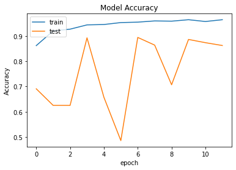

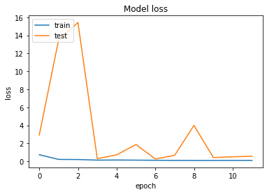

```python
# Graficando la pérdida y la precisión

# Precisión
plt.plot(classifier.history['acc'])
plt.plot(classifier.history['val_acc'])
plt.title('Model Accuracy')
plt.ylabel('Accuracy')
plt.xlabel('epoch')
plt.legend(['train','test'],loc='upper left')
plt.figure(figsize = (60,20))
plt.show()

# Pérdida
plt.plot(classifier.history['loss'],)
plt.plot(classifier.history['val_loss'],)
plt.title('Model loss')
plt.ylabel('loss')
plt.xlabel('epoch')
plt.legend(['train','test'], loc = 'upper left')
plt.figure(figsize = (20,10))
plt.show()
```

## Segundo entrenamiento: termografías

### Cargando el modelo anterior

```python
model = keras.models.load_model(filepath)
```

### Reentrenando con las nuevas imágenes

```python
new_filepath = './models/thermography_best.h5'

checkpoint = ModelCheckpoint(filepath=new_filepath, monitor='val_loss', verbose=1, save_best_only=True, mode='min')

callbacks = [checkpoint, early_stopping, learning_rate_reduction]
```

```python
n_epochs = 20
```

```python
start_time = time.time()

pneum_thermo_transfer = model.fit(
    train_data_gen,
#     steps_per_epoch=(total_train//batch_size),
#     validation_steps=(total_train//batch_size),
    validation_data=validation_data_gen,
    epochs = n_epochs,
    shuffle=True,
    batch_size = batch_size,
    verbose = 1,
    callbacks=callbacks)

total_time = time.time() - start_time
```

```
Epoch 1: val_loss improved from inf to 4.08643, saving model to ./models/thermography_best.h5
Epoch 2: val_loss did not improve from 4.08643
Epoch 3: val_loss did not improve from 4.08643

Epoch 3: ReduceLROnPlateau reducing learning rate to 2.700000040931627e-05.
Epoch 4: val_loss improved from 4.08643 to 0.84526, saving model to ./models/thermography_best.h5
Epoch 5: val_loss did not improve from 0.84526
Epoch 6: val_loss did not improve from 0.84526

Epoch 6: ReduceLROnPlateau reducing learning rate to 8.100000013655517e-06.
Epoch 7: val_loss did not improve from 0.84526
Epoch 8: val_loss did not improve from 0.84526

Epoch 8: ReduceLROnPlateau reducing learning rate to 2.429999949526973e-06.
Epoch 9: val_loss did not improve from 0.84526
```

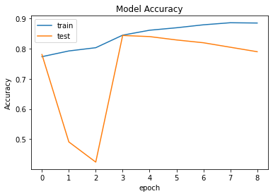

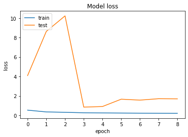

```python
plt.plot(pneum_thermo_transfer.history['acc'])
plt.plot(pneum_thermo_transfer.history['val_acc'])
plt.title('Model Accuracy')
plt.ylabel('Accuracy')
plt.xlabel('epoch')
plt.legend(['train','test'],loc='upper left')
plt.figure(figsize = (60,20))
plt.show()

plt.plot(pneum_thermo_transfer.history['loss'],)
plt.plot(pneum_thermo_transfer.history['val_loss'],)
plt.title('Model loss')
plt.ylabel('loss')
plt.xlabel('epoch')
plt.legend(['train','test'], loc = 'upper left')
plt.figure(figsize = (20,10))
plt.show()
```

# Prueba

```python
model = keras.models.load_model(new_filepath)
```

```python
result = model.evaluate(test_data_gen, batch_size=batch_size)
print(f"Perdida: {result[0]}, Presición: {result[1]}")
```

```
Perdida: 0.885919451713562, Presición: 0.7353735566139221
```

## Observando la distribución de las predicciones para determinar un humbral

```python
Y_pred = model.predict(test_data_gen)
```

```python
## extracting NG and G pred, then order and then
ng_items = len(test_data_gen.classes) - np.count_nonzero(test_data_gen.classes)
ng_ypred = np.copy(Y_pred[0:ng_items])
g_items = np.count_nonzero(test_data_gen.classes)
g_ypred = np.copy(Y_pred[ng_items:])
```

```python
import pandas as pd
ng_analysis = [0,0,0,0,0,0,0,0,0,0]
for i in range(ng_items):
    if ng_ypred[i] <= .1:
        ng_analysis[0] += 1
    elif .1 < ng_ypred[i] <= .2:
        ng_analysis[1] += 1
    elif .2 < ng_ypred[i] <= .3:
        ng_analysis[2] += 1
    elif .3 < ng_ypred[i] <= .4:
        ng_analysis[3] += 1
    elif .4 < ng_ypred[i] <= .5:
        ng_analysis[4] += 1
    elif .5 < ng_ypred[i] <= .6:
        ng_analysis[5] += 1
    elif .6 < ng_ypred[i] <= .7:
        ng_analysis[6] += 1
    elif .7 < ng_ypred[i] <= .8:
        ng_analysis[7] += 1
    elif .8 < ng_ypred[i] <= .9:
        ng_analysis[8] += 1
    elif .9 < ng_ypred[i] <= 1:
        ng_analysis[9] += 1
    else:
        0
g_analysis = [0,0,0,0,0,0,0,0,0,0]
for i in range(g_items):
    if g_ypred[i] <= .1:
        g_analysis[0] += 1
    elif .1 < g_ypred[i] <= .2:
        g_analysis[1] += 1
    elif .2 < g_ypred[i] <= .3:
        g_analysis[2] += 1
    elif .3 < g_ypred[i] <= .4:
        g_analysis[3] += 1
    elif .4 < g_ypred[i] <= .5:
        g_analysis[4] += 1
    elif .5 < g_ypred[i] <= .6:
        g_analysis[5] += 1
    elif .6 < g_ypred[i] <= .7:
        g_analysis[6] += 1
    elif .7 < g_ypred[i] <= .8:
        g_analysis[7] += 1
    elif .8 < g_ypred[i] <= .9:
        g_analysis[8] += 1
    elif .9 < g_ypred[i] <= 1:
        g_analysis[9] += 1
    else:
        0

ng = pd.DataFrame(ng_analysis, columns = [''])
ng = ng.set_index([pd.Index(['0-.1','.1-.2','.2-.3','.3-.4','.4-.5','.5-.6','.6-.7','.7-.8','.8-.9','.9-1'])])
ng = ng.transpose()
print('Distribución de los valores de predicción para pacientes enfermas')
print(ng)

g = pd.DataFrame(g_analysis, columns = [''])
g = g.set_index([pd.Index(['0-.1','.1-.2','.2-.3','.3-.4','.4-.5','.5-.6','.6-.7','.7-.8','.8-.9','.9-1'])])
g = g.transpose()
print('Distribución de los valores de predicción para pacientes sanas')
print(g)
```

```
Distribución de los valores de predicción para pacientes enfermas
  0-.1  .1-.2  .2-.3  .3-.4  .4-.5  .5-.6  .6-.7  .7-.8  .8-.9  .9-1
     2     26     41     32      8     15     17     20     11    43
Distribución de los valores de predicción para pacientes sanas
  0-.1  .1-.2  .2-.3  .3-.4  .4-.5  .5-.6  .6-.7  .7-.8  .8-.9  .9-1
    55     14     33     39     47     78     65     55     70   440
```

```python
import statistics
median_ng = statistics.median(ng_ypred)
mean_ng = np.sum(ng_ypred)/len(ng_ypred)
min_ng = np.max(ng_ypred)

mean_g = np.sum(g_ypred)/len(g_ypred)
median_g = statistics.median(g_ypred)
min_g = np.min(g_ypred)

print("Mediana de predicciones en pacientes enfermas:", median_ng)
print("Media de predicciones en pacientes enfermas:", mean_ng)
print("Valor máximo de predicción en pacientes enfermas:", min_ng)

print("Mediana de predicciones en pacientes sanas:",median_g)
print("Media de predicciones en pacientes sanas:",mean_g)
print("Valor máximo de predicción en pacientes sanas:", min_g)
```

[output not shown]

## Estableciendo el humbral y obteniendo la matriz de confusión

```python
threshold = .95
```

```python
confussion_preds = np.copy(Y_pred)
```

```python
# Cambiar esto por una expresión de numpy
confussion_preds2 = np.where(confussion_preds <= threshold, 0, 1)

# Comparar con estos resultados
# for i in range(len(test_data_gen.classes)):
#     if i < np.count_nonzero(test_data_gen.classes) : # iterate through pred of NG
#         if confussion_preds[i] <= threshold :
#             confussion_preds[i] = 0
#         else:
#             confussion_preds[i] = 1
#     else:
#         if confussion_preds[i] >= threshold :
#             confussion_preds[i] = 1
#         else:
#             confussion_preds[i] = 0
```

```python
print(confussion_preds)
print(confussion_preds2)
```

```
[[0.22977296]
 [0.23666345]
 [0.24280658]
 ...
 [0.43647042]
 [0.82601756]
 [0.43869716]]
[[0]
 [0]
 [0]
 ...
 [0]
 [0]
 [0]]
```

```python
print(test_data_gen.classes)
print(confussion_preds2)
```

```
[0 0 0 ... 1 1 1]
[[0]
 [0]
 [0]
 ...
 [0]
 [0]
 [0]]
```

```python
confussion_preds.flatten()
```

```
array([0.22977296, 0.23666345, 0.24280658, ..., 0.43647042, 0.82601756,
       0.43869716], dtype=float32)
```

```python
confussion_preds2 = confussion_preds2.flatten()
```

```
Confusion Matrix
[[186  29]
 [514 382]]
Reporte de clasificación
              precision    recall  f1-score   support

     Enferma       0.27      0.87      0.41       215
        Sana       0.93      0.43      0.58       896

    accuracy                           0.51      1111
   macro avg       0.60      0.65      0.50      1111
weighted avg       0.80      0.51      0.55      1111
```

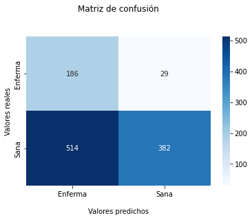

```python
import seaborn as sns

cf_matrix = confusion_matrix(test_data_gen.classes, confussion_preds2)

print('Confusion Matrix')
print(cf_matrix)
print('Reporte de clasificación')
target_names = ['Enferma','Sana']
print(classification_report(test_data_gen.classes, confussion_preds2, target_names=target_names))

ax = sns.heatmap(cf_matrix, annot=True, cmap='Blues', fmt='g')

ax.set_title('Matriz de confusión\n\n');
ax.set_xlabel('\nValores predichos')
ax.set_ylabel('Valores reales');

## Ticket labels - List must be in alphabetical order
ax.xaxis.set_ticklabels(['Enferma','Sana'])
ax.yaxis.set_ticklabels(['Enferma','Sana'])

## Display the visualization of the Confusion Matrix.
plt.show()

plot = ax.get_figure()
plot.savefig("confussion_matrix.jpg")
```

## Clasificando imágenes utilizando el modelo y el humbral

### Pacientes enfermas

```python
images = []
folder_path = test_defect_dir
images_list = os.listdir(folder_path)
for img in images_list:
    img_path = os.path.join(folder_path, img)
    img = plt.imread(img_path)
    images.append(img)
```

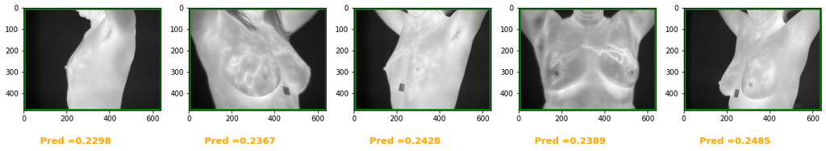

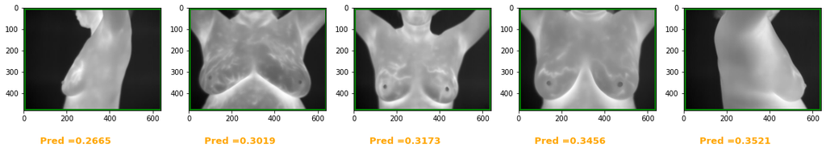

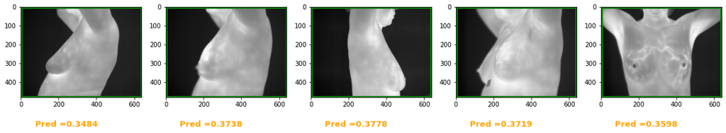

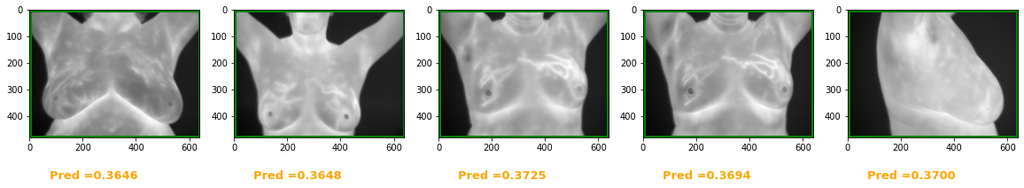

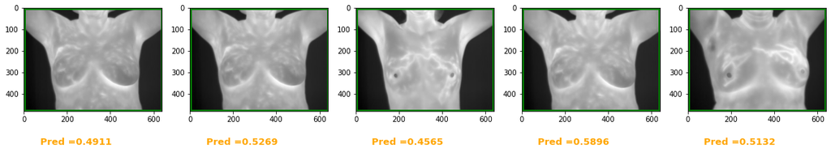

```
True negative = 25
False negative = 0
Total evaluated parts = 25
```

```python
from matplotlib.patches import Rectangle
color = 'none'
true_negative = 0
false_positive = 0

to_show = 10
nrows = 5
ncols = 5

i = 0
for row in range(nrows):
    row += 1
    plt.figure(figsize=(20,10))
    for col in range(ncols):
        col += 1
        # print(ng_ypred[i])
        pred = f"{ng_ypred[i, 0]:.4f}"

        plt.subplot(1, ncols, col)
        plt.text(IMG_SHAPE[0]/2, IMG_SHAPE[1]-5,"Pred =" + pred, color="orange", fontdict={"fontsize":13,"fontweight":'bold',"ha":"center", "va":"baseline"})

        if ng_ypred[i] <= threshold:
            color = 'g'
            true_negative = true_negative +1
        else:
            color = 'r'
            false_positive = false_positive +1
        plt.gca().add_patch(Rectangle((0,0),IMG_SHAPE[1],IMG_SHAPE[0],linewidth=5,edgecolor=color,facecolor='none'))

        plt.imshow(images[i])
        i += 1

    plt.show()

print('True negative =' +' '+ str(true_negative))
print('False negative =' + ' '+ str(false_positive))
print ('Total evaluated parts =' + ' ' + str(true_negative+false_positive))
```

### Pacientes sanas

```python
images = []
folder_path = test_good_dir
images_list = os.listdir(folder_path)
for img in images_list:
    img_path = os.path.join(folder_path, img)
    img = plt.imread(img_path)
    images.append(img)
```

```
Evaluation on Good Parts
```

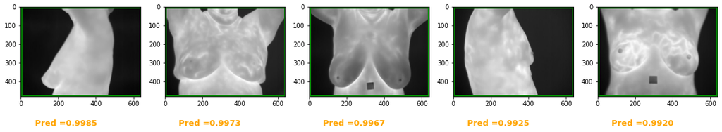

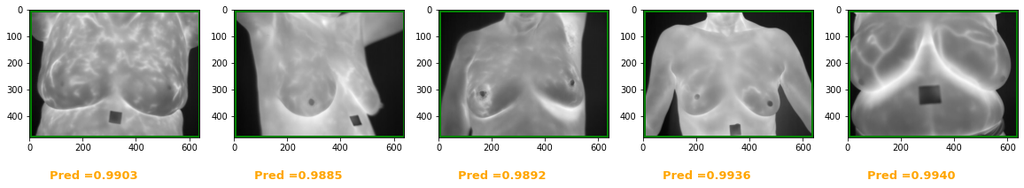

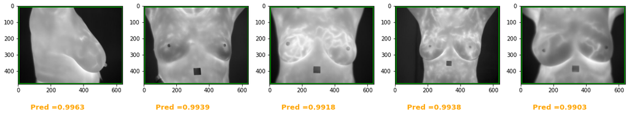

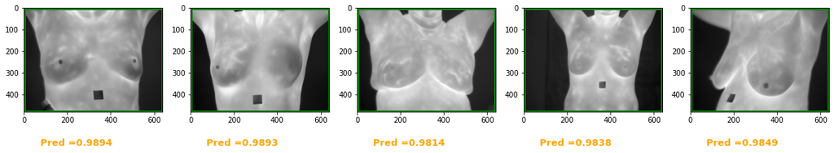

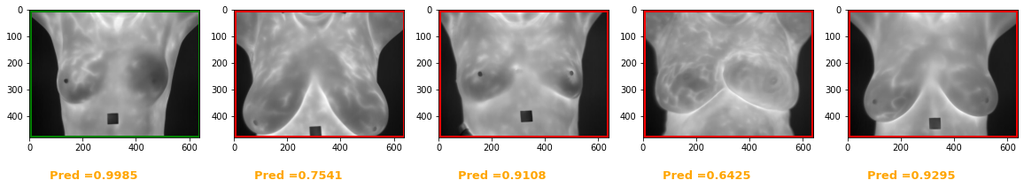

```
True positive = 21
False negative = 4
Total evaluated parts = 25
```

```python
color = 'none'
true_positive = 0
false_negative = 0

print ('Evaluation on Good Parts')

i = 0
for row in range(nrows):
    row += 1
    plt.figure(figsize=(20,10))
    for col in range(ncols):
        col += 1
        pred = f"{g_ypred[i, 0]:.4f}"

        plt.subplot(1, ncols, col)
        plt.text(IMG_SHAPE[0]/2, IMG_SHAPE[1]-5,"Pred =" + pred, color="orange", fontdict={"fontsize":13,"fontweight":'bold',"ha":"center", "va":"baseline"})

        if g_ypred[i] >= threshold:
            color = 'g'
            true_positive = true_positive +1
        else:
            color = 'r'
            false_negative = false_negative +1
        plt.gca().add_patch(Rectangle((0,0),IMG_SHAPE[1],IMG_SHAPE[0],linewidth=5,edgecolor=color,facecolor='none'))

        plt.imshow(images[i])
        i += 1

    plt.show()

print('True positive =' +' '+ str(true_positive))
print('False negative =' + ' '+ str(false_negative))
print ('Total evaluated parts =' + ' ' + str(true_positive+false_negative))
```

# Conclusiónes

- Como se mencionó desde el inicio, esta es solo una herramienta de apoyo y no sustituye el diagnostico de un especialista.
- Es importante establecer un humbral muy alto, ya que queremos evitar el mayor número de falsos negativos (decir que una mujer está sana cuando no es así), y deberiamos mandar a chequeo aunque exista un pequeño indicio de enfermedad.
- Es importante realizar el entrenamiento separando las imágenes de cada paciente. Ya que entregar resultados de pruebas cuando el modelo ha visto imágenes muy similares (p.e. la misma paciente rotada ligeramente) durante el entrenamiento y la prueba invalida la confiabilidad de los mismos.

## Posibles mejoras

El modelo tuvo un desempeño de alrededor de 73% de precisión. Creo, que esta métrica podría mejorar de las siguientes maneras:

- **Mejorando la calidad de los datos.**  
  Muchas imágenes estaban borrosas o desenfocadas. Además, muchas tuvieron que eliminarse ya que estaban demasiado movidas o eran muy diferentes al resto.
- **Mejorando el modelo neuronal.**  
  El modelo utilizado fue el que se desempeñó mejor después de probar varias arquitecturas. Sin embargo, nunca se debe descartar la idea de hacer mejores modelos neuronales.
- **Aumentando la cantidad de datos.**  
  Sé que esto es dificil, pero tener más imágenes de cada clase ayudaría a mejorar los resultados.
- **Incluir metadata.**  
  Es muy probable que el modelo pueda hacer mejores predicciones si se incluye metadata. Es decir, información extra sobre el paciente, tales como antecedentes, resultados de estudios, etc.